```python
import numpy as np
import pandas as pd
import matplotlib
import matplotlib.pyplot as plt
import seaborn as sns
%matplotlib inline
matplotlib.rcParams.update({'font.size': 12})

from sklearn.decomposition import PCA
from sklearn.cluster import KMeans
from sklearn.metrics import silhouette_score
from sklearn.cluster import SpectralClustering
from sklearn.cluster import MeanShift
from sklearn import mixture
from sklearn.feature_selection import f_classif
```

# Research question

A federal research team has decided to investigate how US communities differ in socioeconomic factors that may be related to crime. Can unsupervised learning be used to quantify differences in US communities?

```python
df = pd.read_csv('Data/crime_data_normalized.csv')
df.head()
```

|  | state | county | community | communityname | fold | population | householdsize | racepctblack | racePctWhite | racePctAsian | ... | LandArea | PopDens | PctUsePubTrans | PolicCars | PolicOperBudg | LemasPctPolicOnPatr | LemasGangUnitDeploy | LemasPctOfficDrugUn | PolicBudgPerPop | ViolentCrimesPerPop |
| --- | --- | --- | --- | --- | --- | --- | --- | --- | --- | --- | --- | --- | --- | --- | --- | --- | --- | --- | --- | --- | --- |
| 0 | 8 | ? | ? | Lakewoodcity | 1 | 0.19 | 0.33 | 0.02 | 0.90 | 0.12 | ... | 0.12 | 0.26 | 0.20 | 0.06 | 0.04 | 0.9 | 0.5 | 0.32 | 0.14 | 0.20 |
| 1 | 53 | ? | ? | Tukwilacity | 1 | 0.00 | 0.16 | 0.12 | 0.74 | 0.45 | ... | 0.02 | 0.12 | 0.45 | ? | ? | ? | ? | 0.00 | ? | 0.67 |
| 2 | 24 | ? | ? | Aberdeentown | 1 | 0.00 | 0.42 | 0.49 | 0.56 | 0.17 | ... | 0.01 | 0.21 | 0.02 | ? | ? | ? | ? | 0.00 | ? | 0.43 |
| 3 | 34 | 5 | 81440 | Willingborotownship | 1 | 0.04 | 0.77 | 1.00 | 0.08 | 0.12 | ... | 0.02 | 0.39 | 0.28 | ? | ? | ? | ? | 0.00 | ? | 0.12 |
| 4 | 42 | 95 | 6096 | Bethlehemtownship | 1 | 0.01 | 0.55 | 0.02 | 0.95 | 0.09 | ... | 0.04 | 0.09 | 0.02 | ? | ? | ? | ? | 0.00 | ? | 0.03 |

5 rows × 128 columns

The dataset includes data taken from the 1990 US Census, 1995 FBI Uniform Crime Report, and 1990 US Law Enforcement Management and Administrative Statistics Survey. Data were normalized within a range of 0-1. Distributions were preserved, except for data that were >3 SD above the mean which were normalized to 1. Relationships within features are preserved while relationships between features are not. One major caveat of this dataset is the relatively small sample size (n=1994).

### To avoid cheating...

I am going to avoid using the ViolentCrimePerPop variable in my clustering to ensure that our clustering algorithms do not cluster using this feature. This will replicate a truly 'unsupervised' approach. If these techniques are effective, we should be able to see a difference in this variable between groups at the end.

### Data Cleaning

Many features contain '?' characters in place of null values. Let's convert these to numerical values and change ? to nan. The first 5 features represents categorical identifiers so these can be ignored for now.

```python
# Get list of object columns to convert
cols = df.iloc[:,5:].select_dtypes('object').columns

# Loop through list and convert to numeric, set ? values to nan
for col in cols:
    df.loc[:,col] = pd.to_numeric(df[col], errors='coerce')

# Check that only county, community, and communityname are the remaining object types
df.select_dtypes('object').columns
```

```
Index(['county', 'community', 'communityname'], dtype='object')
```

```python
drop_list = []

for col in df.columns:
    if df[col].isnull().sum() > 0:
        p =  df[col].isnull().sum()/len(df[col])*100
        drop_list.append(col)
        print(f'Percentage missing for {col} is {p:.2f}%')
```

```
Percentage missing for OtherPerCap is 0.05%
Percentage missing for LemasSwornFT is 84.00%
Percentage missing for LemasSwFTPerPop is 84.00%
Percentage missing for LemasSwFTFieldOps is 84.00%
Percentage missing for LemasSwFTFieldPerPop is 84.00%
Percentage missing for LemasTotalReq is 84.00%
Percentage missing for LemasTotReqPerPop is 84.00%
Percentage missing for PolicReqPerOffic is 84.00%
Percentage missing for PolicPerPop is 84.00%
Percentage missing for RacialMatchCommPol is 84.00%
Percentage missing for PctPolicWhite is 84.00%
Percentage missing for PctPolicBlack is 84.00%
Percentage missing for PctPolicHisp is 84.00%
Percentage missing for PctPolicAsian is 84.00%
Percentage missing for PctPolicMinor is 84.00%
Percentage missing for OfficAssgnDrugUnits is 84.00%
Percentage missing for NumKindsDrugsSeiz is 84.00%
Percentage missing for PolicAveOTWorked is 84.00%
Percentage missing for PolicCars is 84.00%
Percentage missing for PolicOperBudg is 84.00%
Percentage missing for LemasPctPolicOnPatr is 84.00%
Percentage missing for LemasGangUnitDeploy is 84.00%
Percentage missing for PolicBudgPerPop is 84.00%
```

Due to the large numbers of missing data in the above features, let's drop them all with the exception of OtherPerCap. For this feature we will simply impute the mean values for the missing data.

```python
# Remove OtherPerCap from drop list

drop_list.pop(0)

df.drop(labels=drop_list, axis=1, inplace=True)
```

```python
# Impute mean values for nan in OtherPerCap

df.loc[:, 'OtherPerCap'].fillna(df['OtherPerCap'].mean(), inplace=True)
```

```python
# Seperate numeric values for clustering

X = df.iloc[:,5:]
X.drop(labels=['ViolentCrimesPerPop'], axis=1, inplace=True)
```

# Moving forward

```
1. Unknown number of clusters
2. Small sample size (<10k samples)
3. No ground truth
```

To work around these problems, I will use the following two methods.

### 1. Estimating the number of clusters

```
- Conduct PCA to test if it improves clustering
- Extract first 2 principal components for visualization
- Conduct Kmeans over various cluster sizes and plot silhouette score to determine optimal n_clusters
- Compare Kmeans to Spectral Clustering using silhouette score
```

### 2. Using algorithms that don't require knowledge of n_clusters

```
- Mean shift
- VBGMM
```

# PCA

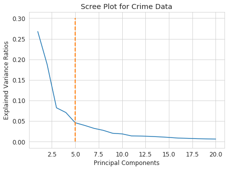

```python
pca = PCA(n_components=20)
pca = pca.fit(X)
components = pd.DataFrame(pca.fit_transform(X), columns=list(range(1,21)))

plt.figure(figsize=(7,5))

sns.lineplot(y=pca.explained_variance_ratio_, x=list(range(1,21)), dashes=True)
plt.plot([5,5],[0,0.3],linewidth=2, linestyle='dashed')

sns.set_style('whitegrid')
plt.title('Scree Plot for Crime Data')
plt.ylabel('Explained Variance Ratios')
plt.xlabel('Principal Components')
plt.show()
```

We get an 'elbow' occuring at the 5th principal component, we will use this for our clustering below. Note the relatively small percentages of explained variance given by each component, this is likely due to the large feature set we are including the in PCA. If the PCA is invalid, or provides us with little information, it should be apparent in the visualization and clustering done below.

# KMeans and estimating n_clusters

### Using entire dataset

```python
# Loop through various numbers of clusters for entire dataset
ns = [2,3,4,5,6,7,8,9,10]
scores = []

for n in ns:
    km = KMeans(n_clusters=n, random_state=2).fit(X)
    score = silhouette_score(X, km.labels_)
    scores.append(score)
```

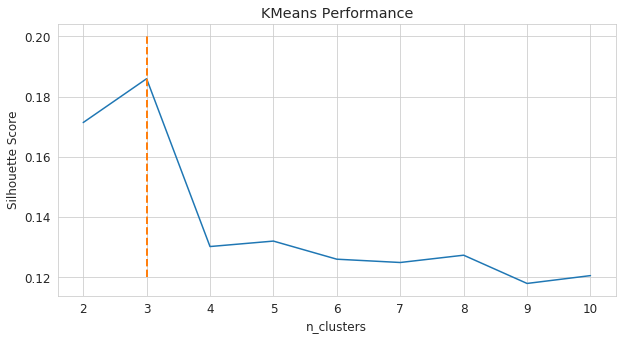

```python
plt.figure(figsize=(10,5))

sns.lineplot(x=ns, y=scores)
plt.plot([3,3],[0.12,0.2],linewidth=2, linestyle='dashed')

plt.title('KMeans Performance')
plt.ylabel('Silhouette Score')
plt.xlabel('n_clusters')

plt.show()
```

Performance shows a peak at 3 clusters. Before we commit to this model for KMeans, let's compare the performance of this model to clustering after PCA.

### Using various numbers of PCs

```python
# Loop through various numbers of clusters and PCs to find optimal solution

ns = [2,3,4,5,6,7,8,9,10]
scores = []
n_clusters = []
n_components = []

for i in range(components.shape[1]-1):
    X_pca = components.loc[:,:i+2]
    for n in ns:
        km_pca = KMeans(n_clusters=n, random_state=2).fit(X_pca)
        score = silhouette_score(X_pca, km_pca.labels_)
        scores.append(score)
        n_clusters.append(n)
        n_components.append(i+2)

# Create df of scores to visualize and sort

scores_df = pd.DataFrame({'scores': scores, 'n_clusters': n_clusters, 'n_components': n_components})
```

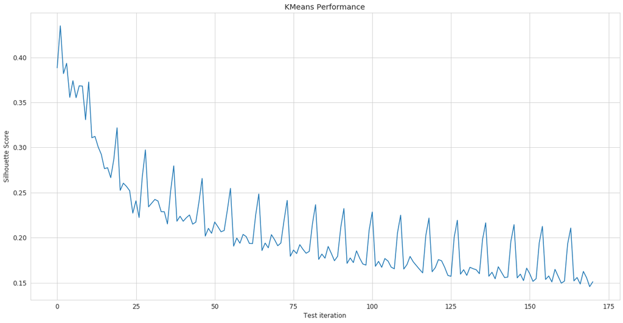

```python
plt.figure(figsize=(20,10))

sns.lineplot(x=range(len(scores)),y=scores)

plt.title('KMeans Performance')
plt.ylabel('Silhouette Score')
plt.xlabel('Test iteration')

plt.show()
```

```python
scores_df.loc[scores_df['scores'].idxmax(),:]
```

```
scores          0.435023
n_clusters      3.000000
n_components    2.000000
Name: 1, dtype: float64
```

The above graph gives us a clear insight into how cluster size and the number of PCs used in our model effect performance. There is a peak in performance at 3 clusters and 2 PCs. While the Scree Plot suggests we include 5 PCs, our KMeans clustering algorithm performed better with just the first 2. Additionally, our silhouette score is more than double the score we got when using the entire feature set. Let's plot our best performing model.

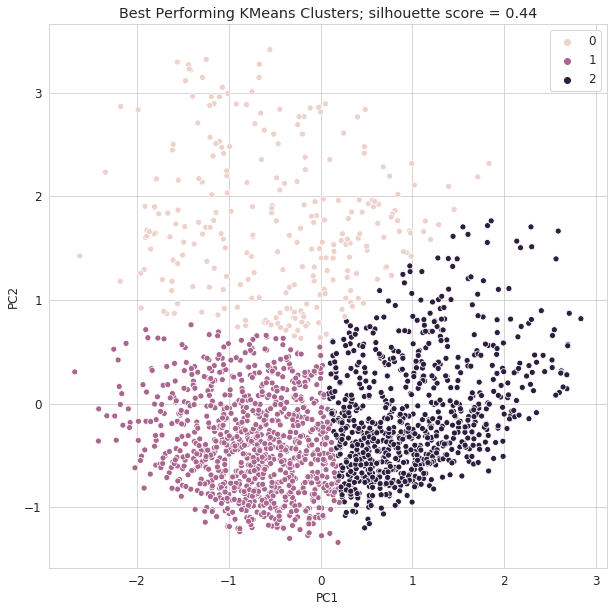

```python
# KMeans with 3 clusters, modeled off of the first 2 PC's, save score to compare later

km = KMeans(n_clusters=3, random_state=2).fit(components.loc[:,:2])
km_score = silhouette_score(components.loc[:,:2], km.labels_)

# Plot clusters against first 2 principal components

plt.figure(figsize=(10,10))

sns.scatterplot(x=components[1],y=components[2],hue=km.labels_)
plt.title(f'Best Performing KMeans Clusters; silhouette score = {km_score:.2f}')
plt.ylabel('PC2')
plt.xlabel('PC1')
plt.show()
```

We can see that the clusters have well defined boundries when plotted against the first 2 principal components (PCs). The 0 cluster is less dense than the other two clusters. Let's compare the results above to Spectral Clustering.

# Spectral Clustering

```python
# Loop through various numbers of clusters and PCs to find optimal solution

ns = [2,3,4,5,6,7,8,9,10]
scores = []
n_clusters = []
n_components = []

for i in range(components.shape[1]-1):
    X_pca = components.loc[:,:i+2]
    for n in ns:
        sc_pca = SpectralClustering(n_clusters=n, random_state=2).fit(X_pca)
        score = silhouette_score(X_pca, sc_pca.labels_)
        scores.append(score)
        n_clusters.append(n)
        n_components.append(i+2)

# Create df of scores to visualize and sort

scores_df = pd.DataFrame({'scores': scores, 'n_clusters': n_clusters, 'n_components': n_components})
```

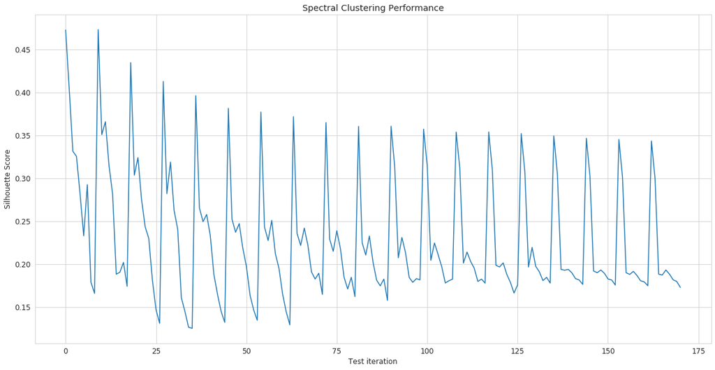

```python
plt.figure(figsize=(20,10))

sns.lineplot(x=range(len(scores)),y=scores)

plt.title('Spectral Clustering Performance')
plt.ylabel('Silhouette Score')
plt.xlabel('Test iteration')

plt.show()
```

```python
scores_df.loc[scores_df['scores'].idxmax(),:]
```

```
scores          0.473558
n_clusters      2.000000
n_components    3.000000
Name: 9, dtype: float64
```

Spectral clustering appears much more consistent as we increase the size of the PCs. What is interesting is that the algorithm performed best when there were only 2 clusters. Let's plot the best performing SC model.

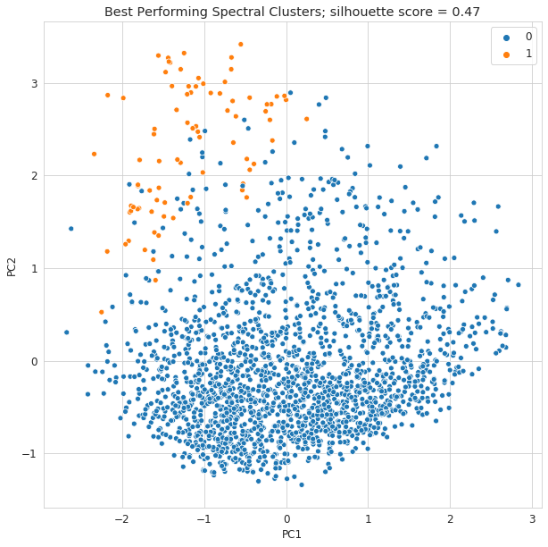

```python
# Spectral Clustering with 2 clusters, modeled off of the first 3 PC's, save score to compare later

sc = SpectralClustering(n_clusters=2, random_state=2).fit(components.loc[:,:3])
sc_score = silhouette_score(components.loc[:,:3], sc.labels_)

# Plot clusters against first 2 principal components

plt.figure(figsize=(10,10))

sns.scatterplot(x=components[1],y=components[2],hue=sc.labels_)
plt.title(f'Best Performing Spectral Clusters; silhouette score = {sc_score:.2f}')
plt.ylabel('PC2')
plt.xlabel('PC1')
plt.show()
```

While the score for the Spectral Clusters is sligtly higher, the clusters that are generated do not have the same visual satisfaction as those generated by the KMeans approach. Let's try two methods that do not require us to set the n_clusters included.

# Mean Shift

```python
# Mean Shift with entire feature set

ms = MeanShift().fit(X)

ms.labels_.sum()
```

```
0
```

Well... our MeanShift algorithm simply clustered all the data into one giant group. Let's see if it does any better with only two PCs.

```python
ms = MeanShift().fit(components.loc[:,:2])
ms.labels_.sum()
```

```
0
```

Unfortunately this does not look too promising. Let's move on to a Gaussian Mixture Model.

# Gaussian Mixture Model

Due to our small sample size (<10k), we will use the Bayesian Gaussian Mixture Model as recommended by scikit-learn. We will generate a quick clusterization and plot to ensure everything is working, then tune the hyperparameters. Note that this algorithm is capable of not using all components set, so the number set in n_components does not necessarily the same as the number of clusters generated.

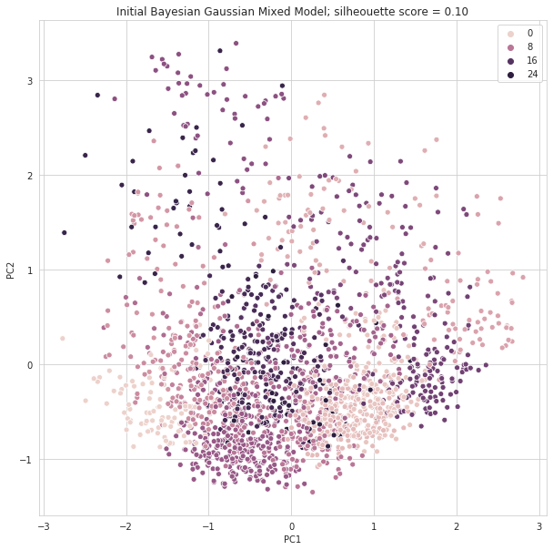

```python
gmm = mixture.BayesianGaussianMixture(n_components=20,
                                      random_state=2).fit(X)

gmm_score = silhouette_score(X, gmm.predict(X))

# Plot clusters against first 2 principal components

plt.figure(figsize=(10,10))

sns.scatterplot(x=components[1],y=components[2],hue=gmm.predict(X))
plt.title(f'Initial Bayesian Gaussian Mixed Model; silhouette score = {gmm_score:.2f}')
plt.ylabel('PC2')
plt.xlabel('PC1')
plt.show()
```

The initial performance is not great. Let's see if we can tune the parameters in this model to outperform our Spectral Cluster above.

```python
n_components = np.arange(1, 401, 20)
models = [mixture.BayesianGaussianMixture(n, warm_start=True,
                                          random_state=2).fit(X) for n in n_components]

log_like = []
s_scores = []

for m in models:

    log_like.append(m.score(X))

    # If the GMM only creates 1 cluster, it will raise an error. We will set these scores to 0

    try:
        s_scores.append(silhouette_score(X,m.predict(X)))

    except:
        s_scores.append(0)
```

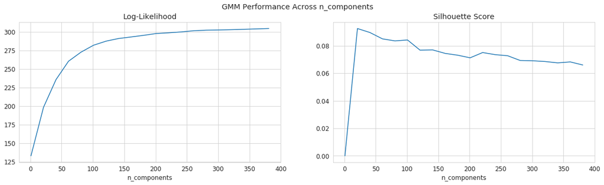

```python
plt.figure(figsize=(20,5))

plt.subplot(1,2,1)
plt.plot(n_components, log_like, label='Log-likelihood')
plt.title('Log-Likelihood')
plt.xlabel('n_components')


plt.subplot(1,2,2)
plt.plot(n_components, s_scores, label='Silhouette Score')
plt.title('Silhouette Score')
plt.xlabel('n_components')


plt.suptitle('GMM Performance Across n_components')
plt.show()
```

Unfortunately it would appear our GMM is not performing very well when compared to the KMeans or Spectral Clustering models. Let's create a plot to visualize exactly what his happening with this model.

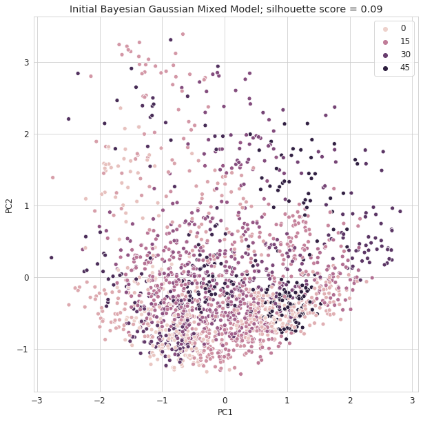

```python
gmm = mixture.BayesianGaussianMixture(n_components=40,
                                      random_state=2).fit(X)

gmm_score = silhouette_score(X, gmm.predict(X))

# Plot clusters against first 2 principal components

plt.figure(figsize=(10,10))

sns.scatterplot(x=components[1],y=components[2],hue=gmm.predict(X))
plt.title(f'Initial Bayesian Gaussian Mixed Model; silhouette score = {gmm_score:.2f}')
plt.ylabel('PC2')
plt.xlabel('PC1')
plt.show()
```

At least when plotted against the first two PCs, it appears the GMM is creating rather chaotic clusters. Due to the clearer interpretation and significantly higher silhouette score, we will proceed with the KMeans cluster model.

# Now what?

We have identified the clusters we want to create, let's evaluate the major differences between communities in our three clusters.

```python
# Add cluster labels to df

df['cluster'] = km.labels_
```

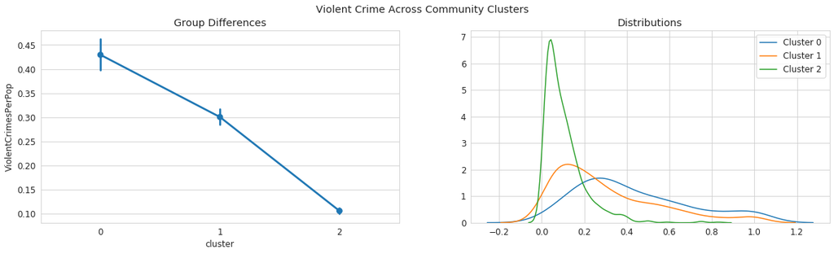

```python
plt.figure(figsize=(20,5))

plt.subplot(1,2,1)
plt.title('Group Differences')
sns.pointplot(x=df['cluster'], y=df['ViolentCrimesPerPop'])

plt.subplot(1,2,2)
plt.title('Distributions')
sns.kdeplot(df.loc[df.cluster==0, 'ViolentCrimesPerPop'], label='Cluster 0')
sns.kdeplot(df.loc[df.cluster==1, 'ViolentCrimesPerPop'], label='Cluster 1')
sns.kdeplot(df.loc[df.cluster==2, 'ViolentCrimesPerPop'], label='Cluster 2')

plt.suptitle('Violent Crime Across Community Clusters')
plt.show()
```

We can clearly see a downward trend in violent crime as we move across the clusters. However there is a large portion of overlap between the clusters. Let's try to identify which features are most different between our clusters.

```python
# Sort features using ANOVA

X_sorted = pd.DataFrame({'feature': X.columns, 'F':f_classif(X,df['cluster'])[0],
                        'p': f_classif(X,df['cluster'])[1]})
X_sorted.sort_values(by='F', inplace=True, ascending=False)
X_sorted.index = range(len(X_sorted.index))
```

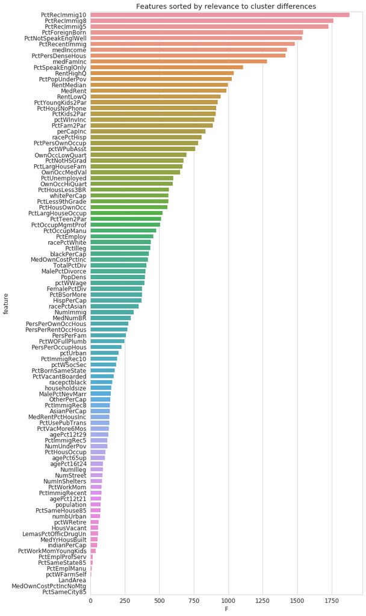

```python
plt.figure(figsize=(10,22))

sns.barplot(y=X_sorted.feature, x=X_sorted.F)
plt.title('Features sorted by relevance to cluster differences')

plt.show()
```

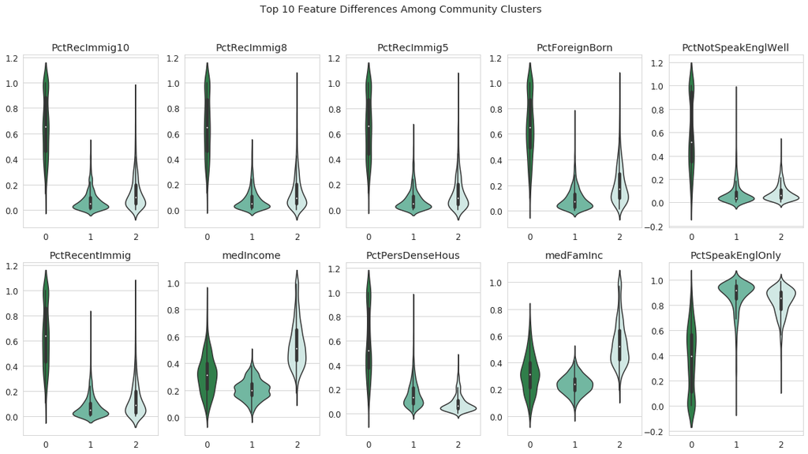

```python
plt.figure(figsize=(20,10))

for i in range(10):
    plt.subplot(2,5,i+1)
    sns.violinplot(y=X_sorted.feature[i],x='cluster',data=df, palette='BuGn_r')
    plt.title(X_sorted.feature[i])
    plt.ylabel('')
    plt.xlabel('')

plt.suptitle('Top 10 Feature Differences Among Community Clusters')
plt.show()
```

# Summary and take-aways

The unsupervised clustering we did with PCA and KMeans was effective in grouping our communities into 3 distinct groups. While using the ViolentCrimesPerPop variable to create a supervised model would have likely given us a better understanding of the specific features that predict violent crime, the unsupervised approach was still useful.

One final caveat for those reading is that the features we sorted using the ANOVA do not provide any indication of causuality. For example, PctRecImmig10 was the value with the greatest F-Statistic from the ANOVA tests, indicating it has the greatest groups differences about the clusters. However, it does not indicate that this variable is having any causual effect on crime in these communities. All we can conclude from these findings is that the KMeans algorithm was able to generate clusters which showed group differences in these features.

Future application of this research should be done with experts in socioeconomic policy to identify how to tackle these issues.